# Chapter 5. Dimensionality and reduction techniques

## Describing the data set

This week I’m learning about dimensionality and reduction techniques. I will be working with ??human??-data. The dataset originates from the United Nations Development Programme and it is about measuring the development of a country with Human Development Index (HDI). More information about the HDI can be found here http://hdr.undp.org/en/content/human-development-index-hdi And more about the calculation of the HDI found here http://hdr.undp.org/sites/default/files/hdr2015_technical_notes.pdf

I’ve been doing some data wrnagling before the analysis and here is briefly summary about my data.

```r
human <- read.table(file="~lottaimmeli/Documents/GitHub/IODS-project/Data/human.csv", header = TRUE, row.names=1, sep = ",")

dim(human)
```

```
## [1] 155   8
```

```r
colnames(human)
```

```
## [1] "Edu.Ratio"  "Labo.Ratio" "Life.Exp"   "Edu.Exp"    "GNI"
## [6] "Mat.Mor"    "Ado.Birth"  "Rep.Per"
```

```r
summary(human)
```

```
##    Edu.Ratio        Labo.Ratio        Life.Exp        Edu.Exp
##  Min.   :0.1717   Min.   :0.1857   Min.   :49.00   Min.   : 5.40
##  1st Qu.:0.7264   1st Qu.:0.5984   1st Qu.:66.30   1st Qu.:11.25
##  Median :0.9375   Median :0.7535   Median :74.20   Median :13.50
##  Mean   :0.8529   Mean   :0.7074   Mean   :71.65   Mean   :13.18
##  3rd Qu.:0.9968   3rd Qu.:0.8535   3rd Qu.:77.25   3rd Qu.:15.20
##  Max.   :1.4967   Max.   :1.0380   Max.   :83.50   Max.   :20.20
##       GNI            Mat.Mor         Ado.Birth         Rep.Per
##  Min.   :   581   Min.   :   1.0   Min.   :  0.60   Min.   : 0.00
##  1st Qu.:  4198   1st Qu.:  11.5   1st Qu.: 12.65   1st Qu.:12.40
##  Median : 12040   Median :  49.0   Median : 33.60   Median :19.30
##  Mean   : 17628   Mean   : 149.1   Mean   : 47.16   Mean   :20.91
##  3rd Qu.: 24512   3rd Qu.: 190.0   3rd Qu.: 71.95   3rd Qu.:27.95
##  Max.   :123124   Max.   :1100.0   Max.   :204.80   Max.   :57.50
```

```r
head(human)
```

```
##             Edu.Ratio Labo.Ratio Life.Exp Edu.Exp   GNI Mat.Mor Ado.Birth
## Norway      1.0072389  0.8908297     81.6    17.5 64992       4       7.8
## Australia   0.9968288  0.8189415     82.4    20.2 42261       6      12.1
## Switzerland 0.9834369  0.8251001     83.0    15.8 56431       6       1.9
## Denmark     0.9886128  0.8840361     80.2    18.7 44025       5       5.1
## Netherlands 0.9690608  0.8286119     81.6    17.9 45435       6       6.2
## Germany     0.9927835  0.8072289     80.9    16.5 43919       7       3.8
##             Rep.Per
## Norway         39.6
## Australia      30.5
## Switzerland    28.5
## Denmark        38.0
## Netherlands    36.9
## Germany        36.9
```

I have a data of 155 countries and 8 variables of each country. First one can see the name of the country and the there are some indicators about the country’s development.

*Empowerment:* Edu.Ratio = Proportion of females with at least secondary education / Proportion of males with at least secondary education Labo.Ratio = Proportion of females in the labour force / Proportion of males in the labour force Rep.Per = Percetange of female representatives in parliament

*Health and knowledge:* Life.Exp = Life expectancy at birth Edu.Exp = Expected years of schooling GNI = Gross National Income per capita Mat.Mor = Maternal mortality ratio Ado.Birth = Adolescent birth rate

```r
#looking the structude of the data

str(human)
```

```
## 'data.frame':    155 obs. of  8 variables:
##  $ Edu.Ratio : num  1.007 0.997 0.983 0.989 0.969 ...
##  $ Labo.Ratio: num  0.891 0.819 0.825 0.884 0.829 ...
##  $ Life.Exp  : num  81.6 82.4 83 80.2 81.6 80.9 80.9 79.1 82 81.8 ...
##  $ Edu.Exp   : num  17.5 20.2 15.8 18.7 17.9 16.5 18.6 16.5 15.9 19.2 ...
##  $ GNI       : int  64992 42261 56431 44025 45435 43919 39568 52947 42155 32689 ...
##  $ Mat.Mor   : int  4 6 6 5 6 7 9 28 11 8 ...
##  $ Ado.Birth : num  7.8 12.1 1.9 5.1 6.2 3.8 8.2 31 14.5 25.3 ...
##  $ Rep.Per   : num  39.6 30.5 28.5 38 36.9 36.9 19.9 19.4 28.2 31.4 ...
```

```r
library(tidyverse)
```

[figure not shown]

```r
library(dplyr)
library(ggplot2)
library(GGally)
#Also making a graphical overview of the data
gather(human) %>% ggplot(aes(value)) + facet_wrap("key", scales = "free") + geom_bar()
```

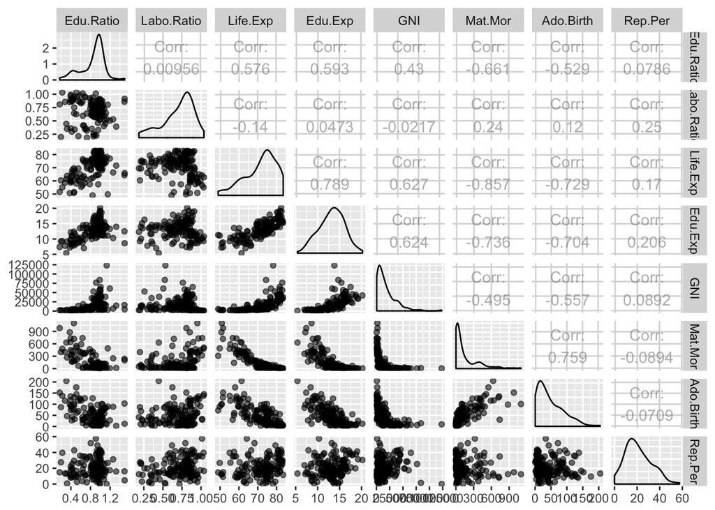

```r
h <- ggpairs(human, mapping = aes(alpha=0.5), lower=list(combo =wrap("facethist", bins=20)))
h
```

Here can be seen a graphical overview and a summary of the data. All the variables are numeric, one as a interval and other continous numeric variables. Only the Edu.Exp variable is normally distributed.

Let’s study the relationship between the variables with correlation matrix.

```r
#making a correlation matrix and drawing a correlation plot to be able to visualie it better and for easier interpretation

library(corrplot)
library(tidyverse)

correlation <- cor(human)
correlation %>% round(digits=2)
```

```
##            Edu.Ratio Labo.Ratio Life.Exp Edu.Exp   GNI Mat.Mor Ado.Birth
## Edu.Ratio       1.00       0.01     0.58    0.59  0.43   -0.66     -0.53
## Labo.Ratio      0.01       1.00    -0.14    0.05 -0.02    0.24      0.12
## Life.Exp        0.58      -0.14     1.00    0.79  0.63   -0.86     -0.73
## Edu.Exp         0.59       0.05     0.79    1.00  0.62   -0.74     -0.70
## GNI             0.43      -0.02     0.63    0.62  1.00   -0.50     -0.56
## Mat.Mor        -0.66       0.24    -0.86   -0.74 -0.50    1.00      0.76
## Ado.Birth      -0.53       0.12    -0.73   -0.70 -0.56    0.76      1.00
## Rep.Per         0.08       0.25     0.17    0.21  0.09   -0.09     -0.07
##            Rep.Per
## Edu.Ratio     0.08
## Labo.Ratio    0.25
## Life.Exp      0.17
## Edu.Exp       0.21
## GNI           0.09
## Mat.Mor      -0.09
## Ado.Birth    -0.07
## Rep.Per       1.00
```

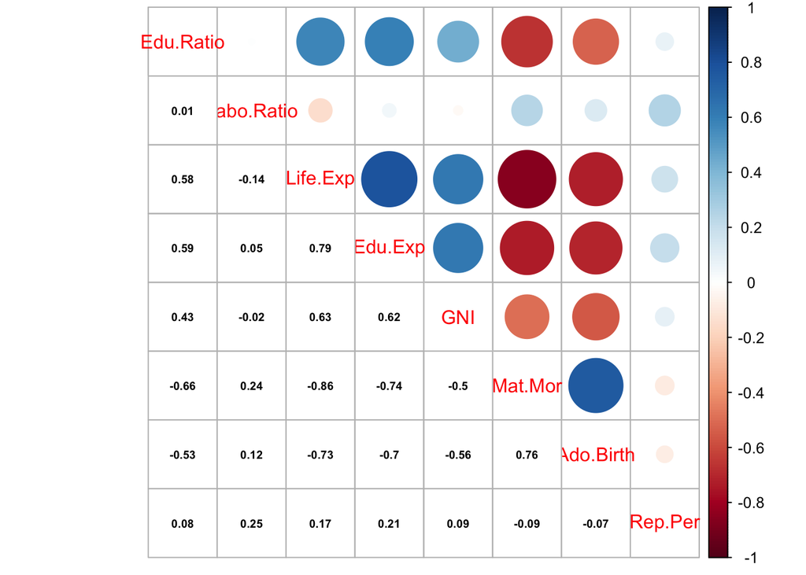

```r
corrplot.mixed(correlation, lower.col = "black", number.cex = .6)
```

Here can be seen that percetange of female representatives in parliament (Rep.Per) or Proportion of females in the labour force / Proportion of males in the labour force (Labo.Ratio) don’t seem to have strong correlations with any of the other variables.

The maternal mortality ratio (Mat.Mor) and life expectancy have strong negative correlation. Meaning that when maternal mortality ratio gets higher life expactancy gets lower, which makes sense. Also adolescence birth ratio (Ado.Birth) has strong negative correlation with life expectancy. Higher education datio and GNI seems to affect positively to life expactancy.

## Principal component analysis (PCA)

First I make the PCA to the non-standardised data.

Principal Component Analysis (PCA) can be performed by two slightly different matrix decomposition methods from linear algebra: the Eigenvalue Decomposition and the Singular Value Decomposition (SVD). The function prcomp() function uses the SVD and is the preferred, more numerically accurate method.

```r
#Making PCA with SVD method
pca_human <- prcomp(human)
sum_pca_human<-summary(pca_human)
sum_pca_human
```

```
## Importance of components:
##                              PC1      PC2   PC3   PC4   PC5   PC6    PC7
## Standard deviation     1.854e+04 185.5219 25.19 11.45 3.766 1.566 0.1912
## Proportion of Variance 9.999e-01   0.0001  0.00  0.00 0.000 0.000 0.0000
## Cumulative Proportion  9.999e-01   1.0000  1.00  1.00 1.000 1.000 1.0000
##                           PC8
## Standard deviation     0.1591
## Proportion of Variance 0.0000
## Cumulative Proportion  1.0000
```

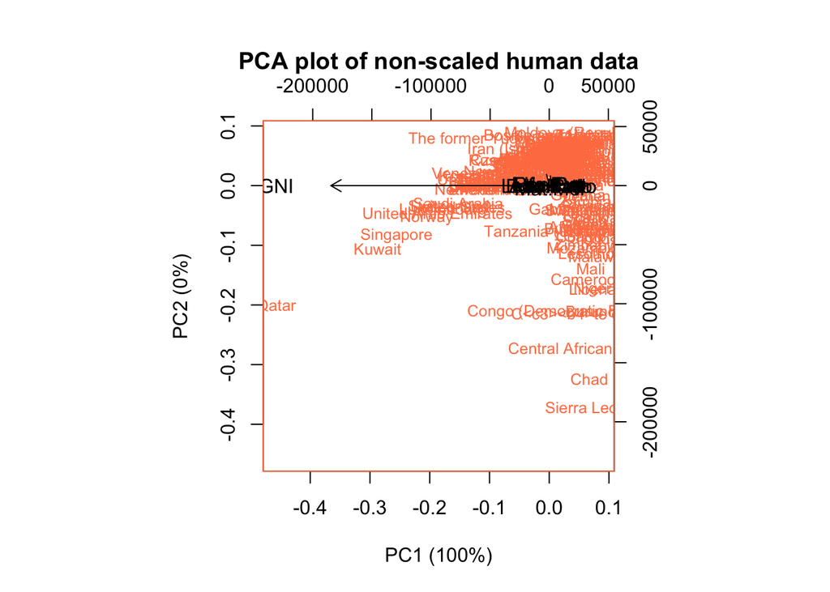

```r
pca_pr <- round(100*sum_pca_human$importance[2, ], digits = 1)
pc_lab<-paste0(names(pca_pr), " (", pca_pr, "%)")


biplot(pca_human, choices = 1:2, cex= c(0.8,1.0), col=c("coral", "black"), xlab = pc_lab[1], ylab = pc_lab[2], main = "PCA plot of non-scaled human data")
```

Now almost all the variables are gathered in a one courner and I get only one arrow. The other arrows are of zero length and indeterminate angle so the are skipped. Because the PCA is sensitive to the relative scaling of the original features and it assumes that features with larger variance are more important than features with smaller variance without the scaling my biplot looks like this. The GNI has the largest variance it becomes dominant here.

Standardisation of the data might be a good idea. So next I’m going to standardise the data and do the PCA again.

```r
#Standardise the data and make the data matrix as data frame for the further analysis.

human_scaled <- scale(human)
str(human_scaled)
```

```
##  num [1:155, 1:8] 0.639 0.596 0.54 0.562 0.481 ...
##  - attr(*, "dimnames")=List of 2
##   ..$ : chr [1:155] "Norway" "Australia" "Switzerland" "Denmark" ...
##   ..$ : chr [1:8] "Edu.Ratio" "Labo.Ratio" "Life.Exp" "Edu.Exp" ...
##  - attr(*, "scaled:center")= Named num [1:8] 8.53e-01 7.07e-01 7.17e+01 1.32e+01 1.76e+04 ...
##   ..- attr(*, "names")= chr [1:8] "Edu.Ratio" "Labo.Ratio" "Life.Exp" "Edu.Exp" ...
##  - attr(*, "scaled:scale")= Named num [1:8] 2.42e-01 1.99e-01 8.33 2.84 1.85e+04 ...
##   ..- attr(*, "names")= chr [1:8] "Edu.Ratio" "Labo.Ratio" "Life.Exp" "Edu.Exp" ...
```

```r
summary(human_scaled)
```

```
##    Edu.Ratio         Labo.Ratio         Life.Exp          Edu.Exp
##  Min.   :-2.8189   Min.   :-2.6247   Min.   :-2.7188   Min.   :-2.7378
##  1st Qu.:-0.5233   1st Qu.:-0.5484   1st Qu.:-0.6425   1st Qu.:-0.6782
##  Median : 0.3503   Median : 0.2316   Median : 0.3056   Median : 0.1140
##  Mean   : 0.0000   Mean   : 0.0000   Mean   : 0.0000   Mean   : 0.0000
##  3rd Qu.: 0.5958   3rd Qu.: 0.7350   3rd Qu.: 0.6717   3rd Qu.: 0.7126
##  Max.   : 2.6646   Max.   : 1.6632   Max.   : 1.4218   Max.   : 2.4730
##       GNI             Mat.Mor          Ado.Birth          Rep.Per
##  Min.   :-0.9193   Min.   :-0.6992   Min.   :-1.1325   Min.   :-1.8203
##  1st Qu.:-0.7243   1st Qu.:-0.6496   1st Qu.:-0.8394   1st Qu.:-0.7409
##  Median :-0.3013   Median :-0.4726   Median :-0.3298   Median :-0.1403
##  Mean   : 0.0000   Mean   : 0.0000   Mean   : 0.0000   Mean   : 0.0000
##  3rd Qu.: 0.3712   3rd Qu.: 0.1932   3rd Qu.: 0.6030   3rd Qu.: 0.6127
##  Max.   : 5.6890   Max.   : 4.4899   Max.   : 3.8344   Max.   : 3.1850
```

```r
class(human_scaled)
```

```
## [1] "matrix"
```

```r
human_scaled<- as.data.frame(human_scaled)

#Make the pca again with SVD method


pca_human_s <- prcomp(human_scaled)

sum_pca_human_s<-summary(pca_human_s)
pca_pr_s <- round(100*sum_pca_human_s$importance[2, ], digits = 1)
pc_lab<-paste0(names(pca_pr_s), " (", pca_pr_s, "%)")

sum_pca_human_var_s<-sum_pca_human_s$sdev^2
sum_pca_human_var_s
```

```
## [1] 4.2883701 1.2989625 0.7657100 0.6066276 0.4381862 0.2876242 0.2106805
## [8] 0.1038390
```

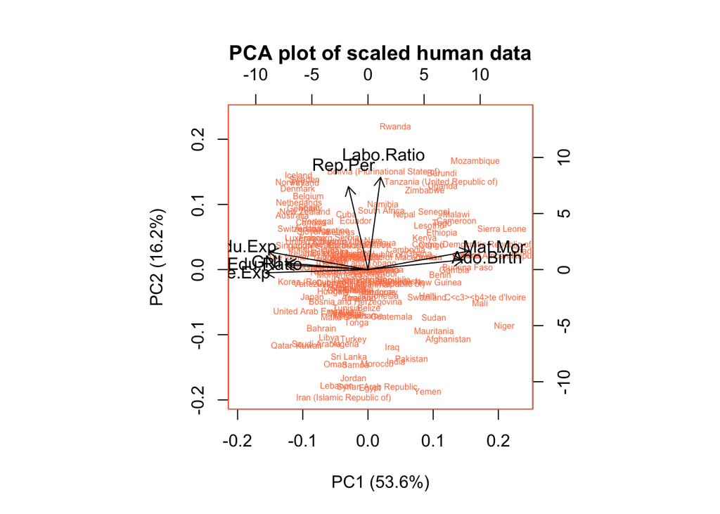

```r
biplot(pca_human_s, choices = 1:2, cex= c(0.5,1.0), col=c("coral", "black"), xlab = pc_lab[1], ylab = pc_lab[2], main = "PCA plot of scaled human data")
```

The standarisation helps a lot. Now the relative scaling between the variables is more similar and the GNI (with largest variance) doesn’t run over the other variables.

Edu.Exp, GNI, Edu.Ratio and Life.Exp are situated together and the arrows share a small angle meaning that these variables have high positive correlation. The arrows of Mat.Mor and Ado.Birth are directed to the opposite direction meaning that they have high negative correlation with the earlier mentioned features. All these factors have high angle with Labo.Ratio and Rep. Per meaning that there is not high correlation.

The angle between a feature and a PC axis can be interpret as the correlation between the two. Small angle = high positive correlation.

The length of the arrows are proportional to the standard deviations of the features and they seem to be pretty similar with the different variables.

## Multiple Correspondence Analysis (MCA)

Next I will be doing some MCA. For this I need the FactoMineR package.

```r
library(FactoMineR)
```

From this packages I will be using the tea data. Now let’s see how the data looks like.

```r
data(tea)
colnames(tea)
```

```
##  [1] "breakfast"        "tea.time"         "evening"
##  [4] "lunch"            "dinner"           "always"
##  [7] "home"             "work"             "tearoom"
## [10] "friends"          "resto"            "pub"
## [13] "Tea"              "How"              "sugar"
## [16] "how"              "where"            "price"
## [19] "age"              "sex"              "SPC"
## [22] "Sport"            "age_Q"            "frequency"
## [25] "escape.exoticism" "spirituality"     "healthy"
## [28] "diuretic"         "friendliness"     "iron.absorption"
## [31] "feminine"         "sophisticated"    "slimming"
## [34] "exciting"         "relaxing"         "effect.on.health"
```

```r
summary(tea)
```

```
##          breakfast           tea.time          evening          lunch
##  breakfast    :144   Not.tea time:131   evening    :103   lunch    : 44
##  Not.breakfast:156   tea time    :169   Not.evening:197   Not.lunch:256
##
##
##
##
##
##         dinner           always          home           work
##  dinner    : 21   always    :103   home    :291   Not.work:213
##  Not.dinner:279   Not.always:197   Not.home:  9   work    : 87
##
##
##
##
##
##         tearoom           friends          resto          pub
##  Not.tearoom:242   friends    :196   Not.resto:221   Not.pub:237
##  tearoom    : 58   Not.friends:104   resto    : 79   pub    : 63
##
##
##
##
##
##         Tea         How           sugar                     how
##  black    : 74   alone:195   No.sugar:155   tea bag           :170
##  Earl Grey:193   lemon: 33   sugar   :145   tea bag+unpackaged: 94
##  green    : 33   milk : 63                  unpackaged        : 36
##                  other:  9
##
##
##
##                   where                 price          age        sex
##  chain store         :192   p_branded      : 95   Min.   :15.00   F:178
##  chain store+tea shop: 78   p_cheap        :  7   1st Qu.:23.00   M:122
##  tea shop            : 30   p_private label: 21   Median :32.00
##                             p_unknown      : 12   Mean   :37.05
##                             p_upscale      : 53   3rd Qu.:48.00
##                             p_variable     :112   Max.   :90.00
##
```

[output cut: 25 more lines]

```
##  feminine    :129   Not.sophisticated: 85   No.slimming:255
##  Not.feminine:171   sophisticated    :215   slimming   : 45
##
##
##
##
##
##         exciting          relaxing              effect.on.health
##  exciting   :116   No.relaxing:113   effect on health   : 66
##  No.exciting:184   relaxing   :187   No.effect on health:234
##
##
##
##
##
```

```r
str(tea)
```

```
## 'data.frame':    300 obs. of  36 variables:
##  $ breakfast       : Factor w/ 2 levels "breakfast","Not.breakfast": 1 1 2 2 1 2 1 2 1 1 ...
##  $ tea.time        : Factor w/ 2 levels "Not.tea time",..: 1 1 2 1 1 1 2 2 2 1 ...
##  $ evening         : Factor w/ 2 levels "evening","Not.evening": 2 2 1 2 1 2 2 1 2 1 ...
##  $ lunch           : Factor w/ 2 levels "lunch","Not.lunch": 2 2 2 2 2 2 2 2 2 2 ...
##  $ dinner          : Factor w/ 2 levels "dinner","Not.dinner": 2 2 1 1 2 1 2 2 2 2 ...
##  $ always          : Factor w/ 2 levels "always","Not.always": 2 2 2 2 1 2 2 2 2 2 ...
##  $ home            : Factor w/ 2 levels "home","Not.home": 1 1 1 1 1 1 1 1 1 1 ...
##  $ work            : Factor w/ 2 levels "Not.work","work": 1 1 2 1 1 1 1 1 1 1 ...
##  $ tearoom         : Factor w/ 2 levels "Not.tearoom",..: 1 1 1 1 1 1 1 1 1 2 ...
##  $ friends         : Factor w/ 2 levels "friends","Not.friends": 2 2 1 2 2 2 1 2 2 2 ...
##  $ resto           : Factor w/ 2 levels "Not.resto","resto": 1 1 2 1 1 1 1 1 1 1 ...
##  $ pub             : Factor w/ 2 levels "Not.pub","pub": 1 1 1 1 1 1 1 1 1 1 ...
##  $ Tea             : Factor w/ 3 levels "black","Earl Grey",..: 1 1 2 2 2 2 2 1 2 1 ...
##  $ How             : Factor w/ 4 levels "alone","lemon",..: 1 3 1 1 1 1 1 3 3 1 ...
```

[output cut: 22 more lines]

I can see that I have data of 300 observations and 36 variables. Except of the variable “age” all the other variables are categorical with 2 to 7 categories.

With MCA I can analyse the pattern of relationships of several categorical variables. MCA deals with categorical variables, but continuous ones can be used as background (supplementary) variables

For the categorical variables, I can either use the indicator matrix or the Burt matrix in the analysis The Indicator matrix contains all the levels of categorical variables as a binary variables (1 = belongs to category, 0 = if doesn’t) Burt matrix is a matrix of two-way cross-tabulations between all the variables in the dataset

For the further analysis I will not be using all the 36 variables. Let’s choose some of them. And make a summary and graphical overview.

```r
#Choose the column to keep
library(dplyr)
library(tidyverse)
library(FactoMineR)

keep <- c("Tea", "How", "sugar", "sex", "age_Q", "breakfast", "work", "price")

#make a new data set with the selected columns
tea1 <- tea[, keep]
library(GGally)
library(ggplot2)

#summary and visualisation of the tea set with my chosen variables
summary(tea1)
```

```
##         Tea         How           sugar     sex       age_Q
##  black    : 74   alone:195   No.sugar:155   F:178   15-24:92
##  Earl Grey:193   lemon: 33   sugar   :145   M:122   25-34:69
##  green    : 33   milk : 63                          35-44:40
##                  other:  9                          45-59:61
##                                                     +60  :38
##
##          breakfast         work                 price
##  breakfast    :144   Not.work:213   p_branded      : 95
##  Not.breakfast:156   work    : 87   p_cheap        :  7
##                                     p_private label: 21
##                                     p_unknown      : 12
##                                     p_upscale      : 53
##                                     p_variable     :112
```

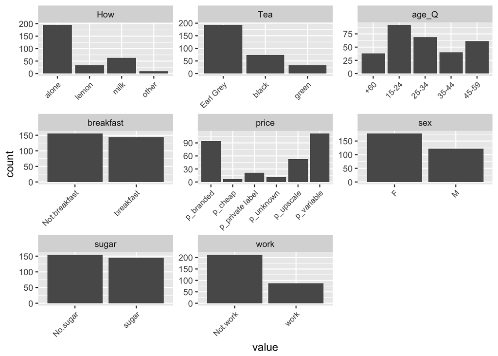

```r
gather(tea1) %>% ggplot(aes(value)) + facet_wrap("key", scales = "free") + geom_bar() + theme(axis.text.x = element_text(angle = 45, hjust =1, size =8))
```

```r
# multiple correspondence analysis
mca <- MCA(tea1, graph = FALSE)

# summary of the model
summary(mca)
```

```
##
## Call:
## MCA(X = tea1, graph = FALSE)
##
##
## Eigenvalues
##                        Dim.1   Dim.2   Dim.3   Dim.4   Dim.5   Dim.6
## Variance               0.219   0.185   0.182   0.162   0.154   0.138
## % of var.              9.737   8.231   8.068   7.191   6.831   6.137
## Cumulative % of var.   9.737  17.968  26.036  33.228  40.058  46.195
##                        Dim.7   Dim.8   Dim.9  Dim.10  Dim.11  Dim.12
## Variance               0.135   0.129   0.127   0.118   0.109   0.109
## % of var.              6.009   5.712   5.653   5.231   4.866   4.835
## Cumulative % of var.  52.203  57.916  63.568  68.799  73.666  78.501
##                       Dim.13  Dim.14  Dim.15  Dim.16  Dim.17  Dim.18
## Variance               0.098   0.092   0.089   0.071   0.068   0.065
## % of var.              4.366   4.102   3.947   3.173   3.035   2.876
## Cumulative % of var.  82.867  86.969  90.916  94.089  97.124 100.000
##
## Individuals (the 10 first)
##              Dim.1    ctr   cos2    Dim.2    ctr   cos2    Dim.3    ctr
## 1         |  0.135  0.028  0.004 |  0.235  0.099  0.012 |  0.882  1.428
## 2         |  0.561  0.479  0.162 |  0.751  1.014  0.290 |  0.022  0.001
## 3         | -0.086  0.011  0.005 |  0.591  0.629  0.239 | -0.418  0.321
## 4         | -0.462  0.325  0.192 | -0.469  0.395  0.198 | -0.087  0.014
## 5         |  0.122  0.023  0.011 |  0.262  0.124  0.052 | -0.029  0.002
## 6         | -0.291  0.129  0.033 | -0.279  0.140  0.031 | -0.188  0.065
## 7         |  0.061  0.006  0.002 |  0.309  0.172  0.058 |  0.143  0.038
## 8         |  0.507  0.392  0.115 |  0.556  0.556  0.138 |  0.057  0.006
## 9         |  0.408  0.254  0.069 |  0.340  0.208  0.048 |  0.615  0.695
## 10        |  0.808  0.993  0.280 |  0.220  0.087  0.021 |  0.407  0.304
##             cos2
## 1          0.163 |
## 2          0.000 |
## 3          0.120 |
## 4          0.007 |
## 5          0.001 |
## 6          0.014 |
## 7          0.012 |
## 8          0.001 |
```

[output cut: 22 more lines]

```
## other       2.634 |   0.066   0.009   0.000   0.200 |
## No.sugar    7.205 |  -0.319   3.620   0.109  -5.703 |
## sugar      -7.205 |   0.341   3.870   0.109   5.703 |
## F           6.016 |  -0.559  12.787   0.457 -11.685 |
##
## Categorical variables (eta2)
##             Dim.1 Dim.2 Dim.3
## Tea       | 0.526 0.158 0.040 |
## How       | 0.107 0.135 0.241 |
## sugar     | 0.228 0.174 0.109 |
## sex       | 0.003 0.121 0.457 |
## age_Q     | 0.550 0.332 0.313 |
## breakfast | 0.000 0.173 0.055 |
## work      | 0.097 0.325 0.056 |
## price     | 0.241 0.063 0.181 |
```

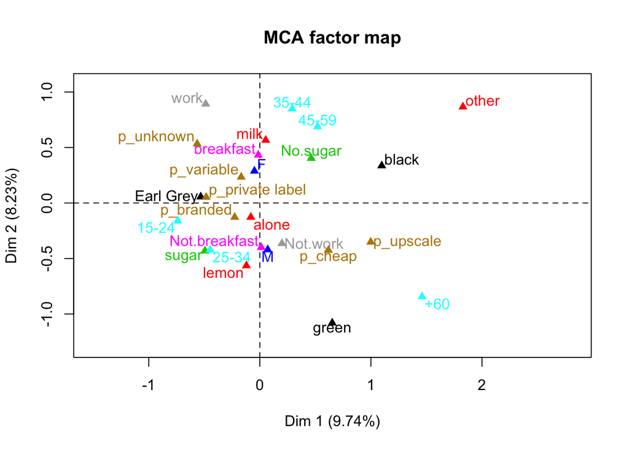

```r
# visualize MCA
plot(mca, invisible=c("ind"), habillage = "quali")
```

**Interpretation of the MCA** The distance between the different points gives a measure of their similarity (or dissimilarity). Younger peole (age cat 15-24 and 25-34) likes to have tea with sugar and at other time than breakfast. And people age 35-44 and 45-59 prefer tea without sugar.